# Risk Factor Analysis

## Outcome Variable

**Outcome Variable:** ever_swasted

## Predictor Variables

**Intervention Variable:** feducyrs

**Adjustment Set:**

unadjusted

## Stratifying Variables

The analysis was stratified on these variable(s):

- agecat
- studyid
- country

## Data Summary

| agecat | studyid | country | feducyrs | ever_swasted | n_cell | n |
| --- | --- | --- | --- | --- | --- | --- |
| 0-24 months | ki0047075b-MAL-ED | BANGLADESH | High | 0 | 50 | 147 |
| 0-24 months | ki0047075b-MAL-ED | BANGLADESH | High | 1 | 4 | 147 |
| 0-24 months | ki0047075b-MAL-ED | BANGLADESH | Low | 0 | 33 | 147 |
| 0-24 months | ki0047075b-MAL-ED | BANGLADESH | Low | 1 | 6 | 147 |
| 0-24 months | ki0047075b-MAL-ED | BANGLADESH | Medium | 0 | 49 | 147 |
| 0-24 months | ki0047075b-MAL-ED | BANGLADESH | Medium | 1 | 5 | 147 |
| 0-24 months | ki0047075b-MAL-ED | INDIA | High | 0 | 43 | 147 |
| 0-24 months | ki0047075b-MAL-ED | INDIA | High | 1 | 1 | 147 |
| 0-24 months | ki0047075b-MAL-ED | INDIA | Low | 0 | 51 | 147 |
| 0-24 months | ki0047075b-MAL-ED | INDIA | Low | 1 | 8 | 147 |
| 0-24 months | ki0047075b-MAL-ED | INDIA | Medium | 0 | 38 | 147 |
| 0-24 months | ki0047075b-MAL-ED | INDIA | Medium | 1 | 6 | 147 |
| 0-24 months | ki0047075b-MAL-ED | NEPAL | High | 0 | 40 | 98 |
| 0-24 months | ki0047075b-MAL-ED | NEPAL | High | 1 | 2 | 98 |
| 0-24 months | ki0047075b-MAL-ED | NEPAL | Low | 0 | 28 | 98 |
| 0-24 months | ki0047075b-MAL-ED | NEPAL | Low | 1 | 0 | 98 |
| 0-24 months | ki0047075b-MAL-ED | NEPAL | Medium | 0 | 26 | 98 |
| 0-24 months | ki0047075b-MAL-ED | NEPAL | Medium | 1 | 2 | 98 |
| 0-24 months | ki0047075b-MAL-ED | PERU | High | 0 | 117 | 250 |
| 0-24 months | ki0047075b-MAL-ED | PERU | High | 1 | 3 | 250 |
| 0-24 months | ki0047075b-MAL-ED | PERU | Low | 0 | 69 | 250 |
| 0-24 months | ki0047075b-MAL-ED | PERU | Low | 1 | 0 | 250 |
| 0-24 months | ki0047075b-MAL-ED | PERU | Medium | 0 | 61 | 250 |
| 0-24 months | ki0047075b-MAL-ED | PERU | Medium | 1 | 0 | 250 |
| 0-24 months | ki0047075b-MAL-ED | SOUTH AFRICA | High | 0 | 43 | 110 |
| 0-24 months | ki0047075b-MAL-ED | SOUTH AFRICA | High | 1 | 0 | 110 |
| 0-24 months | ki0047075b-MAL-ED | SOUTH AFRICA | Low | 0 | 33 | 110 |
| 0-24 months | ki0047075b-MAL-ED | SOUTH AFRICA | Low | 1 | 4 | 110 |
| 0-24 months | ki0047075b-MAL-ED | SOUTH AFRICA | Medium | 0 | 30 | 110 |
| 0-24 months | ki0047075b-MAL-ED | SOUTH AFRICA | Medium | 1 | 0 | 110 |

[output cut: 330 more lines]

The following strata were considered:

- agecat: 0-24 months, studyid: ki0047075b-MAL-ED, country: BANGLADESH
- agecat: 0-24 months, studyid: ki0047075b-MAL-ED, country: INDIA
- agecat: 0-24 months, studyid: ki0047075b-MAL-ED, country: NEPAL
- agecat: 0-24 months, studyid: ki0047075b-MAL-ED, country: PERU
- agecat: 0-24 months, studyid: ki0047075b-MAL-ED, country: SOUTH AFRICA
- agecat: 0-24 months, studyid: ki0047075b-MAL-ED, country: TANZANIA, UNITED REPUBLIC OF
- agecat: 0-24 months, studyid: ki1000304b-SAS-CompFeed, country: INDIA
- agecat: 0-24 months, studyid: ki1000304b-SAS-FoodSuppl, country: INDIA
- agecat: 0-24 months, studyid: ki1017093b-PROVIDE, country: BANGLADESH
- agecat: 0-24 months, studyid: ki1017093c-NIH-Crypto, country: BANGLADESH
- agecat: 0-24 months, studyid: ki1066203-TanzaniaChild2, country: TANZANIA, UNITED REPUBLIC OF
- agecat: 0-24 months, studyid: ki1113344-GMS-Nepal, country: NEPAL
- agecat: 0-24 months, studyid: ki1119695-PROBIT, country: BELARUS
- agecat: 0-24 months, studyid: ki1126311-ZVITAMBO, country: ZIMBABWE
- agecat: 0-24 months, studyid: ki1135781-COHORTS, country: GUATEMALA
- agecat: 0-24 months, studyid: ki1135781-COHORTS, country: INDIA
- agecat: 0-24 months, studyid: ki1135781-COHORTS, country: PHILIPPINES
- agecat: 0-24 months, studyid: ki1148112-LCNI-5, country: MALAWI
- agecat: 0-24 months, studyid: kiGH5241-JiVitA-3, country: BANGLADESH
- agecat: 0-24 months, studyid: kiGH5241-JiVitA-4, country: BANGLADESH
- agecat: 0-6 months, studyid: ki0047075b-MAL-ED, country: BANGLADESH
- agecat: 0-6 months, studyid: ki0047075b-MAL-ED, country: INDIA
- agecat: 0-6 months, studyid: ki0047075b-MAL-ED, country: NEPAL
- agecat: 0-6 months, studyid: ki0047075b-MAL-ED, country: PERU
- agecat: 0-6 months, studyid: ki0047075b-MAL-ED, country: SOUTH AFRICA
- agecat: 0-6 months, studyid: ki0047075b-MAL-ED, country: TANZANIA, UNITED REPUBLIC OF
- agecat: 0-6 months, studyid: ki1000304b-SAS-CompFeed, country: INDIA
- agecat: 0-6 months, studyid: ki1000304b-SAS-FoodSuppl, country: INDIA
- agecat: 0-6 months, studyid: ki1017093b-PROVIDE, country: BANGLADESH
- agecat: 0-6 months, studyid: ki1017093c-NIH-Crypto, country: BANGLADESH
- agecat: 0-6 months, studyid: ki1066203-TanzaniaChild2, country: TANZANIA, UNITED REPUBLIC OF
- agecat: 0-6 months, studyid: ki1113344-GMS-Nepal, country: NEPAL
- agecat: 0-6 months, studyid: ki1119695-PROBIT, country: BELARUS
- agecat: 0-6 months, studyid: ki1126311-ZVITAMBO, country: ZIMBABWE
- agecat: 0-6 months, studyid: ki1135781-COHORTS, country: GUATEMALA
- agecat: 0-6 months, studyid: ki1135781-COHORTS, country: INDIA
- agecat: 0-6 months, studyid: ki1135781-COHORTS, country: PHILIPPINES
- agecat: 0-6 months, studyid: ki1148112-LCNI-5, country: MALAWI
- agecat: 0-6 months, studyid: kiGH5241-JiVitA-3, country: BANGLADESH
- agecat: 0-6 months, studyid: kiGH5241-JiVitA-4, country: BANGLADESH
- agecat: 6-24 months, studyid: ki0047075b-MAL-ED, country: BANGLADESH
- agecat: 6-24 months, studyid: ki0047075b-MAL-ED, country: INDIA
- agecat: 6-24 months, studyid: ki0047075b-MAL-ED, country: NEPAL
- agecat: 6-24 months, studyid: ki0047075b-MAL-ED, country: PERU
- agecat: 6-24 months, studyid: ki0047075b-MAL-ED, country: SOUTH AFRICA
- agecat: 6-24 months, studyid: ki0047075b-MAL-ED, country: TANZANIA, UNITED REPUBLIC OF
- agecat: 6-24 months, studyid: ki1000304b-SAS-CompFeed, country: INDIA
- agecat: 6-24 months, studyid: ki1000304b-SAS-FoodSuppl, country: INDIA
- agecat: 6-24 months, studyid: ki1017093b-PROVIDE, country: BANGLADESH
- agecat: 6-24 months, studyid: ki1017093c-NIH-Crypto, country: BANGLADESH
- agecat: 6-24 months, studyid: ki1066203-TanzaniaChild2, country: TANZANIA, UNITED REPUBLIC OF
- agecat: 6-24 months, studyid: ki1113344-GMS-Nepal, country: NEPAL
- agecat: 6-24 months, studyid: ki1119695-PROBIT, country: BELARUS
- agecat: 6-24 months, studyid: ki1126311-ZVITAMBO, country: ZIMBABWE
- agecat: 6-24 months, studyid: ki1135781-COHORTS, country: GUATEMALA
- agecat: 6-24 months, studyid: ki1135781-COHORTS, country: INDIA
- agecat: 6-24 months, studyid: ki1135781-COHORTS, country: PHILIPPINES
- agecat: 6-24 months, studyid: ki1148112-LCNI-5, country: MALAWI
- agecat: 6-24 months, studyid: kiGH5241-JiVitA-3, country: BANGLADESH
- agecat: 6-24 months, studyid: kiGH5241-JiVitA-4, country: BANGLADESH

### Dropped Strata

Some strata were dropped due to rare outcomes:

- agecat: 0-24 months, studyid: ki0047075b-MAL-ED, country: BANGLADESH
- agecat: 0-24 months, studyid: ki0047075b-MAL-ED, country: INDIA
- agecat: 0-24 months, studyid: ki0047075b-MAL-ED, country: NEPAL
- agecat: 0-24 months, studyid: ki0047075b-MAL-ED, country: PERU
- agecat: 0-24 months, studyid: ki0047075b-MAL-ED, country: SOUTH AFRICA
- agecat: 0-24 months, studyid: ki0047075b-MAL-ED, country: TANZANIA, UNITED REPUBLIC OF
- agecat: 0-24 months, studyid: ki1000304b-SAS-FoodSuppl, country: INDIA
- agecat: 0-24 months, studyid: ki1148112-LCNI-5, country: MALAWI
- agecat: 0-6 months, studyid: ki0047075b-MAL-ED, country: BANGLADESH
- agecat: 0-6 months, studyid: ki0047075b-MAL-ED, country: INDIA
- agecat: 0-6 months, studyid: ki0047075b-MAL-ED, country: NEPAL
- agecat: 0-6 months, studyid: ki0047075b-MAL-ED, country: PERU
- agecat: 0-6 months, studyid: ki0047075b-MAL-ED, country: SOUTH AFRICA
- agecat: 0-6 months, studyid: ki0047075b-MAL-ED, country: TANZANIA, UNITED REPUBLIC OF
- agecat: 0-6 months, studyid: ki1000304b-SAS-CompFeed, country: INDIA
- agecat: 0-6 months, studyid: ki1000304b-SAS-FoodSuppl, country: INDIA
- agecat: 0-6 months, studyid: ki1148112-LCNI-5, country: MALAWI
- agecat: 0-6 months, studyid: kiGH5241-JiVitA-4, country: BANGLADESH
- agecat: 6-24 months, studyid: ki0047075b-MAL-ED, country: BANGLADESH
- agecat: 6-24 months, studyid: ki0047075b-MAL-ED, country: INDIA
- agecat: 6-24 months, studyid: ki0047075b-MAL-ED, country: NEPAL
- agecat: 6-24 months, studyid: ki0047075b-MAL-ED, country: PERU
- agecat: 6-24 months, studyid: ki0047075b-MAL-ED, country: SOUTH AFRICA
- agecat: 6-24 months, studyid: ki0047075b-MAL-ED, country: TANZANIA, UNITED REPUBLIC OF
- agecat: 6-24 months, studyid: ki1000304b-SAS-FoodSuppl, country: INDIA
- agecat: 6-24 months, studyid: ki1017093b-PROVIDE, country: BANGLADESH
- agecat: 6-24 months, studyid: ki1017093c-NIH-Crypto, country: BANGLADESH
- agecat: 6-24 months, studyid: ki1119695-PROBIT, country: BELARUS
- agecat: 6-24 months, studyid: ki1135781-COHORTS, country: GUATEMALA
- agecat: 6-24 months, studyid: ki1148112-LCNI-5, country: MALAWI

## Methods Detail

We’re interested in the causal parameters $E[Y_a]$ for all values of $a \in \mathcal{A}$. These parameters represent the mean outcome if, possibly contrary to fact, we intervened to set all units to have $A=a$. Under the randomization and positivity assumptions, these are identified by the statistical parameters $\psi_a=E_W[E_{Y|A,W}(Y|A=a,W)]$. In addition, we’re interested in the mean of $Y$, $E[Y]$ under no intervention (the observed mean). We will estimate these parameters by using SuperLearner to fit the relevant likelihood factors – $E_{Y|A,W}(Y|A=a,W)$ and $p(A=a|W)$, and then updating our likelihood fit using a joint TMLE.

For unadjusted analyses ($W=\{\}$), initial likelihoods were estimated using Lrnr_glm to estimate the simple $E(Y|A)$ and Lrnr_mean to estimate $p(A)$. For adjusted analyses, a small library containing Lrnr_glmnet, Lrnr_xgboost, and Lrnr_mean was used.

Having estimated these parameters, we will then use the delta method to estimate relative risks and attributable risks relative to a prespecified baseline level of $A$.

# Results Detail

## Results Plots

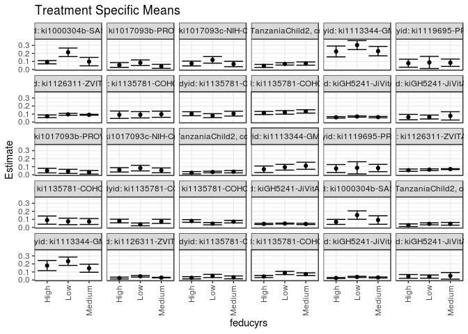

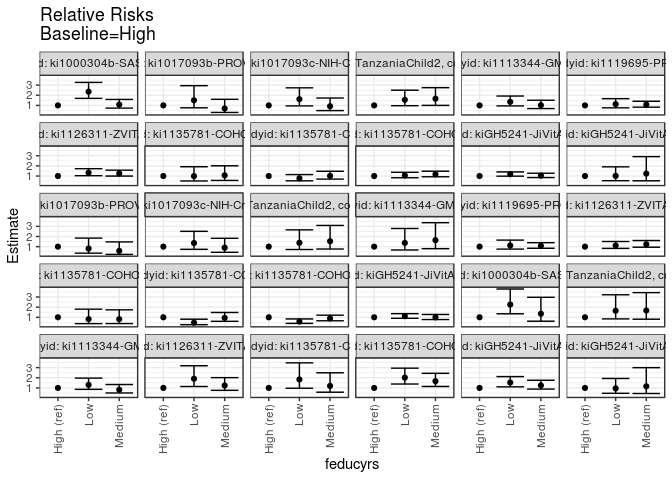

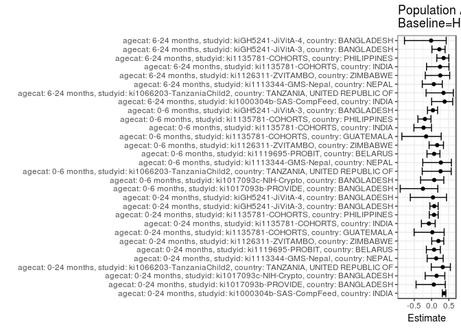

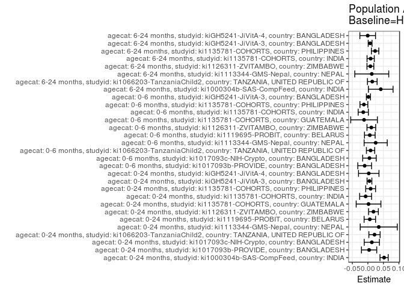

## Results Table

### Parameter: TSM

| agecat | studyid | country | intervention_level | baseline_level | estimate | ci_lower | ci_upper |
| --- | --- | --- | --- | --- | --- | --- | --- |
| 0-24 months | ki1000304b-SAS-CompFeed | INDIA | High | NA | 0.0909091 | 0.0703936 | 0.1114246 |
| 0-24 months | ki1000304b-SAS-CompFeed | INDIA | Low | NA | 0.2139037 | 0.1607755 | 0.2670320 |
| 0-24 months | ki1000304b-SAS-CompFeed | INDIA | Medium | NA | 0.0980392 | 0.0456583 | 0.1504201 |
| 0-24 months | ki1017093b-PROVIDE | BANGLADESH | High | NA | 0.0560345 | 0.0264189 | 0.0856501 |
| 0-24 months | ki1017093b-PROVIDE | BANGLADESH | Low | NA | 0.0840336 | 0.0487611 | 0.1193061 |
| 0-24 months | ki1017093b-PROVIDE | BANGLADESH | Medium | NA | 0.0391304 | 0.0140529 | 0.0642079 |
| 0-24 months | ki1017093c-NIH-Crypto | BANGLADESH | High | NA | 0.0743243 | 0.0444235 | 0.1042252 |
| 0-24 months | ki1017093c-NIH-Crypto | BANGLADESH | Low | NA | 0.1198347 | 0.0788897 | 0.1607797 |
| 0-24 months | ki1017093c-NIH-Crypto | BANGLADESH | Medium | NA | 0.0681818 | 0.0348527 | 0.1015109 |
| 0-24 months | ki1066203-TanzaniaChild2 | TANZANIA, UNITED REPUBLIC OF | High | NA | 0.0445434 | 0.0254575 | 0.0636294 |
| 0-24 months | ki1066203-TanzaniaChild2 | TANZANIA, UNITED REPUBLIC OF | Low | NA | 0.0692913 | 0.0553217 | 0.0832609 |
| 0-24 months | ki1066203-TanzaniaChild2 | TANZANIA, UNITED REPUBLIC OF | Medium | NA | 0.0737952 | 0.0539057 | 0.0936846 |
| 0-24 months | ki1113344-GMS-Nepal | NEPAL | High | NA | 0.2244898 | 0.1569837 | 0.2919959 |
| 0-24 months | ki1113344-GMS-Nepal | NEPAL | Low | NA | 0.3035019 | 0.2472440 | 0.3597599 |
| 0-24 months | ki1113344-GMS-Nepal | NEPAL | Medium | NA | 0.2284264 | 0.1697534 | 0.2870994 |
| 0-24 months | ki1119695-PROBIT | BELARUS | High | NA | 0.0779116 | 0.0281457 | 0.1276776 |
| 0-24 months | ki1119695-PROBIT | BELARUS | Low | NA | 0.0875458 | 0.0121412 | 0.1629504 |
| 0-24 months | ki1119695-PROBIT | BELARUS | Medium | NA | 0.0839397 | 0.0384694 | 0.1294100 |
| 0-24 months | ki1126311-ZVITAMBO | ZIMBABWE | High | NA | 0.0725806 | 0.0564349 | 0.0887263 |
| 0-24 months | ki1126311-ZVITAMBO | ZIMBABWE | Low | NA | 0.0968025 | 0.0846729 | 0.1089320 |
| 0-24 months | ki1126311-ZVITAMBO | ZIMBABWE | Medium | NA | 0.0909886 | 0.0854309 | 0.0965464 |
| 0-24 months | ki1135781-COHORTS | GUATEMALA | High | NA | 0.0921053 | 0.0460953 | 0.1381153 |
| 0-24 months | ki1135781-COHORTS | GUATEMALA | Low | NA | 0.0913462 | 0.0521605 | 0.1305318 |
| 0-24 months | ki1135781-COHORTS | GUATEMALA | Medium | NA | 0.0982906 | 0.0601142 | 0.1364670 |
| 0-24 months | ki1135781-COHORTS | INDIA | High | NA | 0.1040564 | 0.0789155 | 0.1291974 |
| 0-24 months | ki1135781-COHORTS | INDIA | Low | NA | 0.0805085 | 0.0559545 | 0.1050625 |
| 0-24 months | ki1135781-COHORTS | INDIA | Medium | NA | 0.1053922 | 0.0755872 | 0.1351971 |
| 0-24 months | ki1135781-COHORTS | PHILIPPINES | High | NA | 0.1138132 | 0.0943960 | 0.1332304 |
| 0-24 months | ki1135781-COHORTS | PHILIPPINES | Low | NA | 0.1210654 | 0.0988158 | 0.1433150 |
| 0-24 months | ki1135781-COHORTS | PHILIPPINES | Medium | NA | 0.1331361 | 0.1122225 | 0.1540497 |

[output cut: 60 more lines]

### Parameter: E(Y)

| agecat | studyid | country | intervention_level | baseline_level | estimate | ci_lower | ci_upper |
| --- | --- | --- | --- | --- | --- | --- | --- |
| 0-24 months | ki1000304b-SAS-CompFeed | INDIA | NA | NA | 0.1431670 | 0.1130936 | 0.1732405 |
| 0-24 months | ki1017093b-PROVIDE | BANGLADESH | NA | NA | 0.0600000 | 0.0423945 | 0.0776055 |
| 0-24 months | ki1017093c-NIH-Crypto | BANGLADESH | NA | NA | 0.0870712 | 0.0669870 | 0.1071555 |
| 0-24 months | ki1066203-TanzaniaChild2 | TANZANIA, UNITED REPUBLIC OF | NA | NA | 0.0658833 | 0.0559209 | 0.0758458 |
| 0-24 months | ki1113344-GMS-Nepal | NEPAL | NA | NA | 0.2595674 | 0.2244889 | 0.2946458 |
| 0-24 months | ki1119695-PROBIT | BELARUS | NA | NA | 0.0842388 | 0.0288434 | 0.1396342 |
| 0-24 months | ki1126311-ZVITAMBO | ZIMBABWE | NA | NA | 0.0906209 | 0.0857893 | 0.0954524 |
| 0-24 months | ki1135781-COHORTS | GUATEMALA | NA | NA | 0.0942761 | 0.0707571 | 0.1177951 |
| 0-24 months | ki1135781-COHORTS | INDIA | NA | NA | 0.0967519 | 0.0815150 | 0.1119888 |
| 0-24 months | ki1135781-COHORTS | PHILIPPINES | NA | NA | 0.1227336 | 0.1107225 | 0.1347447 |
| 0-24 months | kiGH5241-JiVitA-3 | BANGLADESH | NA | NA | 0.0644960 | 0.0595717 | 0.0694204 |
| 0-24 months | kiGH5241-JiVitA-4 | BANGLADESH | NA | NA | 0.0653266 | 0.0456567 | 0.0849966 |
| 0-6 months | ki1017093b-PROVIDE | BANGLADESH | NA | NA | 0.0414286 | 0.0266555 | 0.0562017 |
| 0-6 months | ki1017093c-NIH-Crypto | BANGLADESH | NA | NA | 0.0659631 | 0.0482810 | 0.0836451 |
| 0-6 months | ki1066203-TanzaniaChild2 | TANZANIA, UNITED REPUBLIC OF | NA | NA | 0.0331515 | 0.0259618 | 0.0403411 |
| 0-6 months | ki1113344-GMS-Nepal | NEPAL | NA | NA | 0.0931780 | 0.0699191 | 0.1164370 |
| 0-6 months | ki1119695-PROBIT | BELARUS | NA | NA | 0.0833546 | 0.0277077 | 0.1390016 |
| 0-6 months | ki1126311-ZVITAMBO | ZIMBABWE | NA | NA | 0.0679929 | 0.0637419 | 0.0722439 |
| 0-6 months | ki1135781-COHORTS | GUATEMALA | NA | NA | 0.0778947 | 0.0537677 | 0.1020217 |
| 0-6 months | ki1135781-COHORTS | INDIA | NA | NA | 0.0642202 | 0.0514517 | 0.0769887 |
| 0-6 months | ki1135781-COHORTS | PHILIPPINES | NA | NA | 0.0669690 | 0.0578174 | 0.0761205 |
| 0-6 months | kiGH5241-JiVitA-3 | BANGLADESH | NA | NA | 0.0448613 | 0.0405987 | 0.0491239 |
| 6-24 months | ki1000304b-SAS-CompFeed | INDIA | NA | NA | 0.1093023 | 0.0732474 | 0.1453573 |
| 6-24 months | ki1066203-TanzaniaChild2 | TANZANIA, UNITED REPUBLIC OF | NA | NA | 0.0408163 | 0.0321620 | 0.0494707 |
| 6-24 months | ki1113344-GMS-Nepal | NEPAL | NA | NA | 0.1918506 | 0.1600242 | 0.2236769 |
| 6-24 months | ki1126311-ZVITAMBO | ZIMBABWE | NA | NA | 0.0321587 | 0.0287656 | 0.0355518 |
| 6-24 months | ki1135781-COHORTS | INDIA | NA | NA | 0.0362989 | 0.0265157 | 0.0460822 |
| 6-24 months | ki1135781-COHORTS | PHILIPPINES | NA | NA | 0.0666667 | 0.0571766 | 0.0761568 |
| 6-24 months | kiGH5241-JiVitA-3 | BANGLADESH | NA | NA | 0.0322895 | 0.0278646 | 0.0367144 |
| 6-24 months | kiGH5241-JiVitA-4 | BANGLADESH | NA | NA | 0.0440806 | 0.0289011 | 0.0592601 |

### Parameter: RR

| agecat | studyid | country | intervention_level | baseline_level | estimate | ci_lower | ci_upper |
| --- | --- | --- | --- | --- | --- | --- | --- |
| 0-24 months | ki1000304b-SAS-CompFeed | INDIA | High | High | 1.0000000 | 1.0000000 | 1.0000000 |
| 0-24 months | ki1000304b-SAS-CompFeed | INDIA | Low | High | 2.3529410 | 1.6943193 | 3.2675843 |
| 0-24 months | ki1000304b-SAS-CompFeed | INDIA | Medium | High | 1.0784313 | 0.7331589 | 1.5863057 |
| 0-24 months | ki1017093b-PROVIDE | BANGLADESH | High | High | 1.0000000 | 1.0000000 | 1.0000000 |
| 0-24 months | ki1017093b-PROVIDE | BANGLADESH | Low | High | 1.4996768 | 0.7636284 | 2.9451898 |
| 0-24 months | ki1017093b-PROVIDE | BANGLADESH | Medium | High | 0.6983278 | 0.3042943 | 1.6025988 |
| 0-24 months | ki1017093c-NIH-Crypto | BANGLADESH | High | High | 1.0000000 | 1.0000000 | 1.0000000 |
| 0-24 months | ki1017093c-NIH-Crypto | BANGLADESH | Low | High | 1.6123216 | 0.9510936 | 2.7332544 |
| 0-24 months | ki1017093c-NIH-Crypto | BANGLADESH | Medium | High | 0.9173554 | 0.4870702 | 1.7277609 |
| 0-24 months | ki1066203-TanzaniaChild2 | TANZANIA, UNITED REPUBLIC OF | High | High | 1.0000000 | 1.0000000 | 1.0000000 |
| 0-24 months | ki1066203-TanzaniaChild2 | TANZANIA, UNITED REPUBLIC OF | Low | High | 1.5555905 | 0.9688125 | 2.4977608 |
| 0-24 months | ki1066203-TanzaniaChild2 | TANZANIA, UNITED REPUBLIC OF | Medium | High | 1.6567018 | 0.9986314 | 2.7484221 |
| 0-24 months | ki1113344-GMS-Nepal | NEPAL | High | High | 1.0000000 | 1.0000000 | 1.0000000 |
| 0-24 months | ki1113344-GMS-Nepal | NEPAL | Low | High | 1.3519632 | 0.9496215 | 1.9247717 |
| 0-24 months | ki1113344-GMS-Nepal | NEPAL | Medium | High | 1.0175358 | 0.6851670 | 1.5111339 |
| 0-24 months | ki1119695-PROBIT | BELARUS | High | High | 1.0000000 | 1.0000000 | 1.0000000 |
| 0-24 months | ki1119695-PROBIT | BELARUS | Low | High | 1.1236547 | 0.7594058 | 1.6626155 |
| 0-24 months | ki1119695-PROBIT | BELARUS | Medium | High | 1.0773705 | 0.8243668 | 1.4080228 |
| 0-24 months | ki1126311-ZVITAMBO | ZIMBABWE | High | High | 1.0000000 | 1.0000000 | 1.0000000 |
| 0-24 months | ki1126311-ZVITAMBO | ZIMBABWE | Low | High | 1.3337227 | 1.0331987 | 1.7216593 |
| 0-24 months | ki1126311-ZVITAMBO | ZIMBABWE | Medium | High | 1.2536211 | 0.9953616 | 1.5788894 |
| 0-24 months | ki1135781-COHORTS | GUATEMALA | High | High | 1.0000000 | 1.0000000 | 1.0000000 |
| 0-24 months | ki1135781-COHORTS | GUATEMALA | Low | High | 0.9917582 | 0.5133851 | 1.9158804 |
| 0-24 months | ki1135781-COHORTS | GUATEMALA | Medium | High | 1.0671551 | 0.5667873 | 2.0092545 |
| 0-24 months | ki1135781-COHORTS | INDIA | High | High | 1.0000000 | 1.0000000 | 1.0000000 |
| 0-24 months | ki1135781-COHORTS | INDIA | Low | High | 0.7737001 | 0.5243156 | 1.1417013 |
| 0-24 months | ki1135781-COHORTS | INDIA | Medium | High | 1.0128365 | 0.6982342 | 1.4691887 |
| 0-24 months | ki1135781-COHORTS | PHILIPPINES | High | High | 1.0000000 | 1.0000000 | 1.0000000 |
| 0-24 months | ki1135781-COHORTS | PHILIPPINES | Low | High | 1.0637197 | 0.8277940 | 1.3668854 |
| 0-24 months | ki1135781-COHORTS | PHILIPPINES | Medium | High | 1.1697770 | 0.9276546 | 1.4750944 |

[output cut: 60 more lines]

### Parameter: PAR

| agecat | studyid | country | intervention_level | baseline_level | estimate | ci_lower | ci_upper |
| --- | --- | --- | --- | --- | --- | --- | --- |
| 0-24 months | ki1000304b-SAS-CompFeed | INDIA | High | NA | 0.0522579 | 0.0390633 | 0.0654526 |
| 0-24 months | ki1017093b-PROVIDE | BANGLADESH | High | NA | 0.0039655 | -0.0206446 | 0.0285756 |
| 0-24 months | ki1017093c-NIH-Crypto | BANGLADESH | High | NA | 0.0127469 | -0.0117311 | 0.0372250 |
| 0-24 months | ki1066203-TanzaniaChild2 | TANZANIA, UNITED REPUBLIC OF | High | NA | 0.0213399 | 0.0032775 | 0.0394024 |
| 0-24 months | ki1113344-GMS-Nepal | NEPAL | High | NA | 0.0350776 | -0.0245741 | 0.0947293 |
| 0-24 months | ki1119695-PROBIT | BELARUS | High | NA | 0.0063271 | -0.0121188 | 0.0247731 |
| 0-24 months | ki1126311-ZVITAMBO | ZIMBABWE | High | NA | 0.0180402 | 0.0023593 | 0.0337211 |
| 0-24 months | ki1135781-COHORTS | GUATEMALA | High | NA | 0.0021708 | -0.0376620 | 0.0420037 |
| 0-24 months | ki1135781-COHORTS | INDIA | High | NA | -0.0073045 | -0.0265109 | 0.0119019 |
| 0-24 months | ki1135781-COHORTS | PHILIPPINES | High | NA | 0.0089204 | -0.0069230 | 0.0247637 |
| 0-24 months | kiGH5241-JiVitA-3 | BANGLADESH | High | NA | 0.0051055 | -0.0026377 | 0.0128487 |
| 0-24 months | kiGH5241-JiVitA-4 | BANGLADESH | High | NA | 0.0028266 | -0.0301421 | 0.0357954 |
| 0-6 months | ki1017093b-PROVIDE | BANGLADESH | High | NA | -0.0102956 | -0.0324867 | 0.0118956 |
| 0-6 months | ki1017093c-NIH-Crypto | BANGLADESH | High | NA | 0.0051522 | -0.0166466 | 0.0269511 |
| 0-6 months | ki1066203-TanzaniaChild2 | TANZANIA, UNITED REPUBLIC OF | High | NA | 0.0086526 | -0.0047325 | 0.0220377 |
| 0-6 months | ki1113344-GMS-Nepal | NEPAL | High | NA | 0.0251508 | -0.0121144 | 0.0624161 |
| 0-6 months | ki1119695-PROBIT | BELARUS | High | NA | 0.0062462 | -0.0109322 | 0.0234246 |
| 0-6 months | ki1126311-ZVITAMBO | ZIMBABWE | High | NA | 0.0111401 | -0.0028821 | 0.0251623 |
| 0-6 months | ki1135781-COHORTS | GUATEMALA | High | NA | -0.0122692 | -0.0551754 | 0.0306370 |
| 0-6 months | ki1135781-COHORTS | INDIA | High | NA | -0.0147744 | -0.0312184 | 0.0016695 |
| 0-6 months | ki1135781-COHORTS | PHILIPPINES | High | NA | -0.0127976 | -0.0255007 | -0.0000944 |
| 0-6 months | kiGH5241-JiVitA-3 | BANGLADESH | High | NA | 0.0017767 | -0.0048037 | 0.0083571 |
| 6-24 months | ki1000304b-SAS-CompFeed | INDIA | High | NA | 0.0415057 | 0.0018316 | 0.0811798 |
| 6-24 months | ki1066203-TanzaniaChild2 | TANZANIA, UNITED REPUBLIC OF | High | NA | 0.0141497 | -0.0013940 | 0.0296933 |
| 6-24 months | ki1113344-GMS-Nepal | NEPAL | High | NA | 0.0125402 | -0.0421899 | 0.0672704 |
| 6-24 months | ki1126311-ZVITAMBO | ZIMBABWE | High | NA | 0.0081134 | -0.0029171 | 0.0191439 |
| 6-24 months | ki1135781-COHORTS | INDIA | High | NA | 0.0089765 | -0.0027014 | 0.0206544 |
| 6-24 months | ki1135781-COHORTS | PHILIPPINES | High | NA | 0.0233297 | 0.0113857 | 0.0352737 |
| 6-24 months | kiGH5241-JiVitA-3 | BANGLADESH | High | NA | 0.0072779 | 0.0011272 | 0.0134287 |
| 6-24 months | kiGH5241-JiVitA-4 | BANGLADESH | High | NA | -0.0005623 | -0.0257754 | 0.0246509 |

### Parameter: PAF

| agecat | studyid | country | intervention_level | baseline_level | estimate | ci_lower | ci_upper |
| --- | --- | --- | --- | --- | --- | --- | --- |
| 0-24 months | ki1000304b-SAS-CompFeed | INDIA | High | NA | 0.3650137 | 0.3112688 | 0.4145647 |
| 0-24 months | ki1017093b-PROVIDE | BANGLADESH | High | NA | 0.0660920 | -0.4482931 | 0.3977847 |
| 0-24 months | ki1017093c-NIH-Crypto | BANGLADESH | High | NA | 0.1463964 | -0.1841883 | 0.3846932 |
| 0-24 months | ki1066203-TanzaniaChild2 | TANZANIA, UNITED REPUBLIC OF | High | NA | 0.3239045 | -0.0082177 | 0.5466206 |
| 0-24 months | ki1113344-GMS-Nepal | NEPAL | High | NA | 0.1351387 | -0.1277274 | 0.3367323 |
| 0-24 months | ki1119695-PROBIT | BELARUS | High | NA | 0.0751095 | -0.1497746 | 0.2560086 |
| 0-24 months | ki1126311-ZVITAMBO | ZIMBABWE | High | NA | 0.1990735 | 0.0062597 | 0.3544759 |
| 0-24 months | ki1135781-COHORTS | GUATEMALA | High | NA | 0.0230263 | -0.5055282 | 0.3660181 |
| 0-24 months | ki1135781-COHORTS | INDIA | High | NA | -0.0754976 | -0.2931812 | 0.1055429 |
| 0-24 months | ki1135781-COHORTS | PHILIPPINES | High | NA | 0.0726808 | -0.0656561 | 0.1930597 |
| 0-24 months | kiGH5241-JiVitA-3 | BANGLADESH | High | NA | 0.0791596 | -0.0487669 | 0.1914819 |
| 0-24 months | kiGH5241-JiVitA-4 | BANGLADESH | High | NA | 0.0432692 | -0.6154784 | 0.4333977 |
| 0-6 months | ki1017093b-PROVIDE | BANGLADESH | High | NA | -0.2485137 | -0.9073454 | 0.1827456 |
| 0-6 months | ki1017093c-NIH-Crypto | BANGLADESH | High | NA | 0.0781081 | -0.3185292 | 0.3554298 |
| 0-6 months | ki1066203-TanzaniaChild2 | TANZANIA, UNITED REPUBLIC OF | High | NA | 0.2610019 | -0.2696929 | 0.5698817 |
| 0-6 months | ki1113344-GMS-Nepal | NEPAL | High | NA | 0.2699223 | -0.2542614 | 0.5750379 |
| 0-6 months | ki1119695-PROBIT | BELARUS | High | NA | 0.0749353 | -0.1318412 | 0.2439358 |
| 0-6 months | ki1126311-ZVITAMBO | ZIMBABWE | High | NA | 0.1638419 | -0.0697619 | 0.3464337 |
| 0-6 months | ki1135781-COHORTS | GUATEMALA | High | NA | -0.1575100 | -0.8601099 | 0.2797042 |
| 0-6 months | ki1135781-COHORTS | INDIA | High | NA | -0.2300590 | -0.5105114 | -0.0016774 |
| 0-6 months | ki1135781-COHORTS | PHILIPPINES | High | NA | -0.1910972 | -0.3949698 | -0.0170202 |
| 0-6 months | kiGH5241-JiVitA-3 | BANGLADESH | High | NA | 0.0396035 | -0.1184202 | 0.1752998 |
| 6-24 months | ki1000304b-SAS-CompFeed | INDIA | High | NA | 0.3797331 | 0.0026273 | 0.6142556 |
| 6-24 months | ki1066203-TanzaniaChild2 | TANZANIA, UNITED REPUBLIC OF | High | NA | 0.3466667 | -0.1582084 | 0.6314614 |
| 6-24 months | ki1113344-GMS-Nepal | NEPAL | High | NA | 0.0653647 | -0.2680802 | 0.3111294 |
| 6-24 months | ki1126311-ZVITAMBO | ZIMBABWE | High | NA | 0.2522932 | -0.1813758 | 0.5267674 |
| 6-24 months | ki1135781-COHORTS | INDIA | High | NA | 0.2472945 | -0.1440653 | 0.5047787 |
| 6-24 months | ki1135781-COHORTS | PHILIPPINES | High | NA | 0.3499458 | 0.1520489 | 0.5016570 |
| 6-24 months | kiGH5241-JiVitA-3 | BANGLADESH | High | NA | 0.2253961 | 0.0115887 | 0.3929539 |
| 6-24 months | kiGH5241-JiVitA-4 | BANGLADESH | High | NA | -0.0127551 | -0.7846182 | 0.4252704 |